# Modelagem do Prêmio frequência-severidade por Bullman-Straub, Random Forest e XGboost com grupos tarifários agrupados por experiência do analista

# Introdução

Este trabalho utiliza dados extraídos do sistema AUTOSEG, disponibilizado pela Superintendência de Seguros Privados (SUSEP), referentes ao modelo de veículo Hyundai HB20, nos anos de 2017, 2018, 2019 e 2020. Ressalta-se que os dados referentes ao ano de 2016 não estavam disponíveis no sistema no momento da extração das informações, por isso não foi considerado.

O sistema AUTOSEG permite a realização de consultas on-line sobre dados estatísticos do seguro de automóveis. As informações disponibilizadas têm como base os arquivos enviados semestralmente pelas seguradoras, conforme previsto no item 9 do Manual de Orientação anexo à Circular SUSEP nº 522/2015, abrangendo dados de apólices vigentes e sinistros ocorridos durante o período analisado.

## Carregar dados

```r
df_regiao <- read.csv("C:/Pós em Atuária/Trabalho de Conclusão de Curso/Analise/Base/HB20_2017-2020_Agrupada_Regiao.csv", encoding = "UTF-8")
df_regiao_ano <- read.csv("C:/Pós em Atuária/Trabalho de Conclusão de Curso/Analise/Base/HB20_2017-2020_Agrupado_Regiao_Ano.csv", encoding = "UTF-8")
```

A base de dados analisada é composta por 1640 observações e 16 variáveis, conforme descritas a seguir:

- Ano: Ano de ocorrência do dado;
- Categoria: Categoria do veículo segurado;
- Região: Unidade da federação ou região onde o seguro foi contratado;
- Grupo: Identificação do modelo do veículo;
- Ano_Modelo: Ano de fabricação/modelo do veículo;
- Sexo: Sexo do condutor principal;
- Faixa_Etária: Faixa etária do condutor principal;
- IS_Media.RS.: Importância segurada média, em reais;
- Expostos: Quantidade de exposições ao risco (veículos-seguro);
- Premio_Medio.RS.: Prêmio médio pago pelo seguro, em reais;
- Freq_Inc_Roubo: Frequência de sinistros por roubo ou furto;
- Ind_Inc_Roubo.RS.: Indenização paga por sinistros de roubo ou furto, em reais;
- Freq_Colisao: Frequência de sinistros por colisão;
- Ind_Colisao.RS.: Indenização paga por sinistros de colisão, em reais;
- Freq_Outros: Frequência de sinistros classificados como outros;
- Ind_Outras.RS.: Indenização paga por sinistros classificados como outros, em reais.

## 2. Medidas de avaliação de risco

A partir da análise dos dados de sinistro, após identificar possiveis grupos de risco para segregar os dados em classes, foram observadas as razoes de Sinistros/Expostos mensais e Razões Frequência para o grupamento por região.

# ==========================================

# AGRUPANDO POR GRUPOS TARIFARIOS - Analista

# ==========================================

```r
grupoAlt = unique((df_regiao %>% filter(Grupo_Tarifario == "Alto"))$Regiao) # alto indice de colisão
grupoMed = unique((df_regiao %>% filter(Grupo_Tarifario == "Medio"))$Regiao) # medio indice de colisão
grupoBai = unique((df_regiao %>% filter(Grupo_Tarifario == "Baixo"))$Regiao) # baixo indice de colisão

df = df_regiao_ano %>%
  mutate(Grupo_Tarifario = case_when(
    Regiao %in% grupoAlt ~ "Alto",
    Regiao %in% grupoMed ~ "Medio",
    Regiao %in% grupoBai ~ "Baixo")) %>%
  group_by(Grupo_Tarifario, Ano) %>%
  summarise(Expostos = sum(Expostos),
            Freq_Total = sum(Freq_Total),
            Ind_Total = sum(Ind_Total)) %>%
  mutate(Frequencia = Freq_Total / Expostos,
         Severidade = case_when(
           Freq_Total > 0 ~ Ind_Total/Freq_Total,
           TRUE ~ 0),
         Razao = Ind_Total / Expostos)
View(df)
```

### 3.2.1 Análise Exploratória por Classe de Riscos

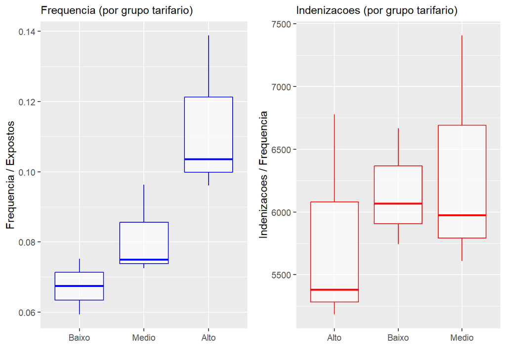

### Versão Bayesiana do modelo de Bühlmann-Straub

#====================== #===== SEVERIDADE ===== #======================

```r
## dados para severidade experiência do analista
df = dados_sev %>%
  filter(Ano != 2020)

alto.BS = df$Severidade[df$Grupo_Tarifario == "Alto"]
medio.BS = df$Severidade[df$Grupo_Tarifario == "Medio"]
baixo.BS = df$Severidade[df$Grupo_Tarifario == "Baixo"]

M2 = matrix(c(alto.BS, medio.BS, baixo.BS), byrow = TRUE, ncol = 3)
colnames(M2) = c("2017", "2018", "2019")
rownames(M2) = c("Alto", "Medio", "Baixo")
M2
```

```
##           2017     2018     2019
## Alto  5182.324 5379.799 6778.000
## Medio 5610.106 5975.867 7408.495
## Baixo 5742.991 6067.017 6667.294
```

```r
#model <- stan_model("bulhmann-straub-severidade-02.stan")

# ----------------------
# ---- rodando stan ----
# ----------------------

options(mc.cores = parallel::detectCores())
rstan_options(auto_write = TRUE)

stan.dados <- list(x = M2, m = 3, n = 3)   # dados que entram no modelo

amostras <- stan("C:/Pós em Atuária/Trabalho de Conclusão de Curso/Analise/Base/bulhmann-straub-severidade-02.stan",
                 data = stan.dados,
                 warmup = 30000,
                 control = list(adapt_delta=0.999),
                 iter = 100000,
                 thin = 30,
                 chains = 2)
```

A implementação foi realizada em linguagem Stan, utilizando o algoritmo HMC (Hamiltonian Monte Carlo). Foram adotadas 100.000 iterações por cadeia, com descarte de 30.000 para *warmup*, além de um *thin* de 30 e duas cadeias em paralelo.

## 4.6 Análise das Saídas e Diagnóstico das Cadeias de Markov

```r
# ---------------------------
# ---- analisando saidas ----
# ---------------------------
s.post <- extract(amostras)   # transforma as saidas (objeto do rstan) em listas do R
names(s.post)
```

```
## [1] "mu"        "sigma2vet" "mu0"       "sigma"     "tau"       "w"
## [7] "k"         "lp__"
```

```r
saveRDS(s.post,"output-bulhmann-straub-severidade-ajustado.rds")

mu.s<- s.post$mu # premio de credibilidade

## o erro padrão
std.error.post<- apply(s.post$mu, 2, sd)
std.error.post
```

```
## [1] 554.3341 535.0933 428.1434
```

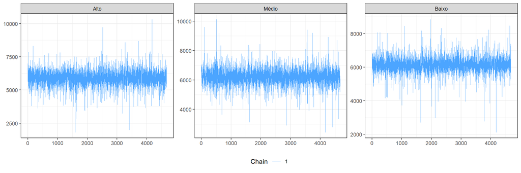

Traceplot das cadeias MCMC para os grupos Alto, Médio e Baixo

```
##        mu[1]        mu[2]        mu[3] sigma2vet[1] sigma2vet[2] sigma2vet[3]
##    1.0003202    0.9999882    0.9996405    0.9998591    1.0000947    0.9997381
##          mu0        sigma          tau         w[1]         w[2]         w[3]
##    0.9997840    0.9998795    1.0000813    1.0003387    1.0000799    1.0001154
##         k[1]         k[2]         k[3]         lp__
##          NaN          NaN          NaN    1.0012519
```

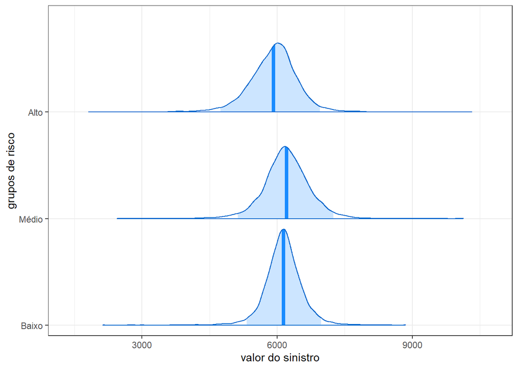

```r
## densidade a posteriori
color_scheme_set("brightblue")
colnames(mu.s)<- c('Alto', 'Médio', 'Baixo')
mcmc_areas(mu.s, prob=0.95, point_est="mean")+ theme_bw() +
  labs(x = "valor do sinistro", y = "grupos de risco", title = NULL)
```

```r
## intervalos de credibilidade de 95%
q025<- function(x){quantile(x,0.025)}
q975<- function(x){quantile(x,0.975)}

summary.post <- data.frame(Pbayes= apply(s.post$mu,2,median),
                          lowerIC= apply(s.post$mu, 2, q025), upperIC= apply(s.post$mu, 2, q975))
summary.post
```

```
##     Pbayes  lowerIC upperIC
## 1 5951.416 4743.223 6951.88
## 2 6200.671 5131.948 7248.93
## 3 6138.094 5320.786 6971.19
```

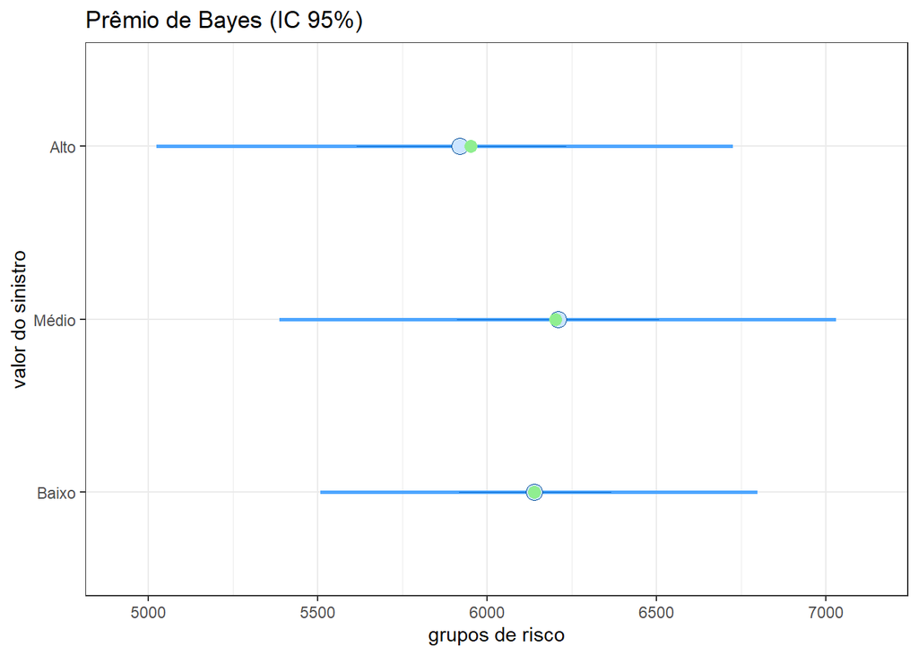

```r
### estimativa pontual a posteriori e intervalo de credibilidade
color_scheme_set("brightblue")
mcmc_intervals(mu.s, point_est="mean", inner_size=0.025, outer_size=0.975) + theme_bw() +
  labs(x = "grupos de risco", y = "valor do sinistro", title = "Prêmio de Bayes (IC 95%)") +
  geom_point(aes(x=summary.post$Pbayes,y=3:1), col="lightgreen", size=3)
```

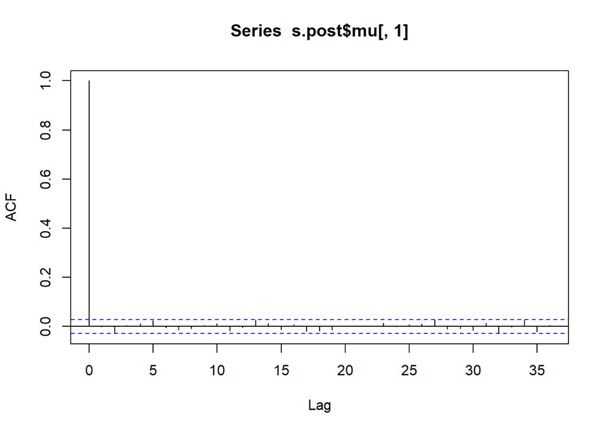

```r
### autocorrelacao das cadeias
acf(s.post$mu[,1])
```

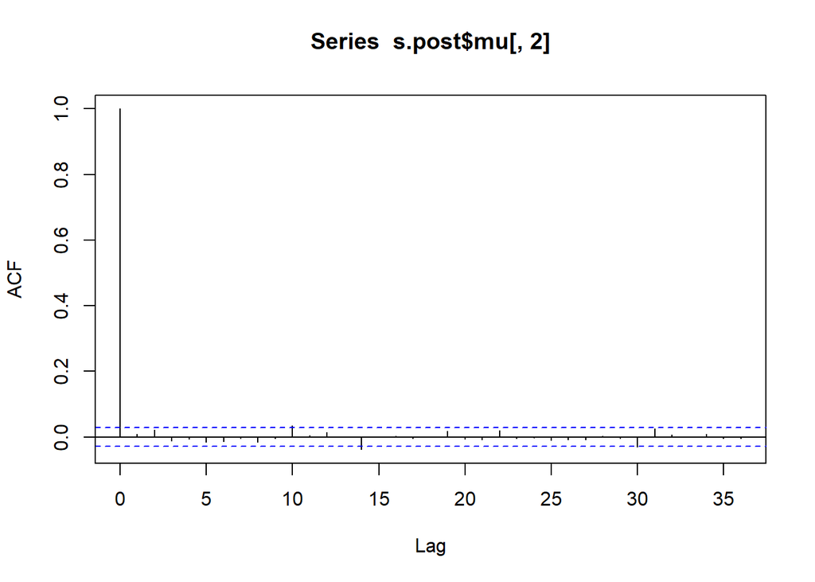

```r
acf(s.post$mu[,2])
```

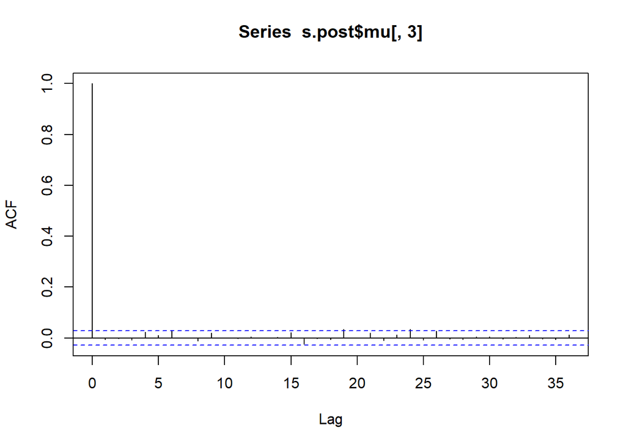

```r
acf(s.post$mu[,3])
```

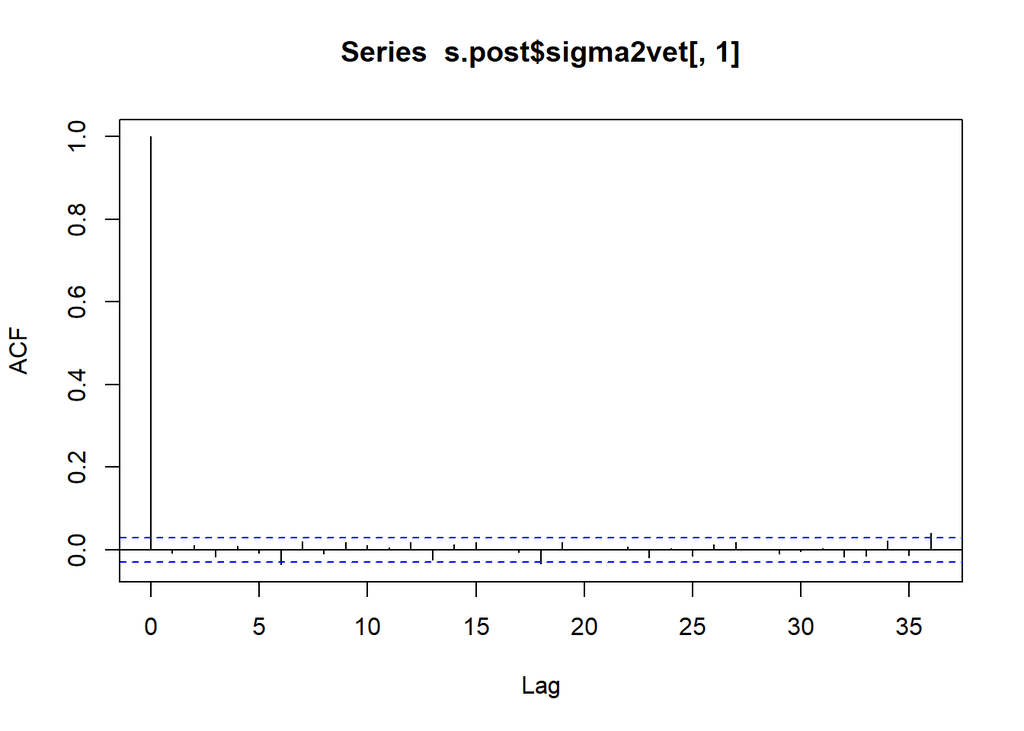

```r
acf(s.post$sigma2vet[,1])
```

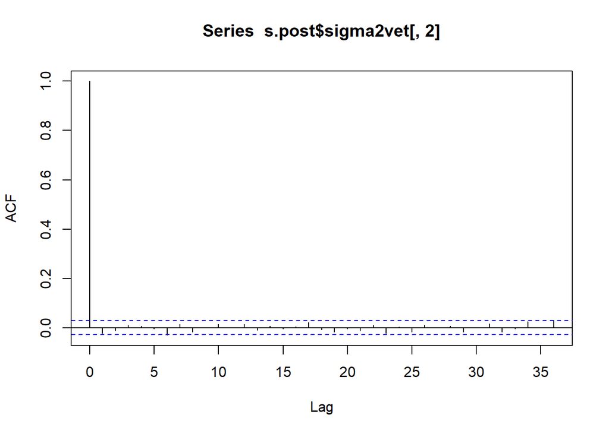

```r
acf(s.post$sigma2vet[,2])
```

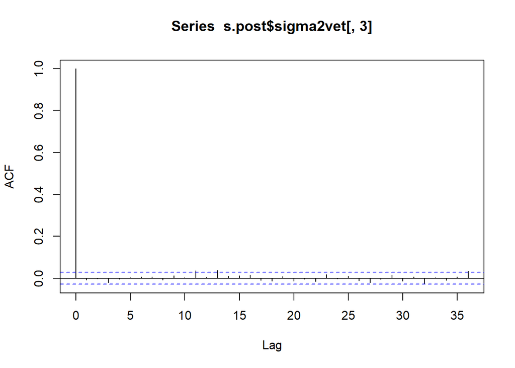

```r
acf(s.post$sigma2vet[,3])
```

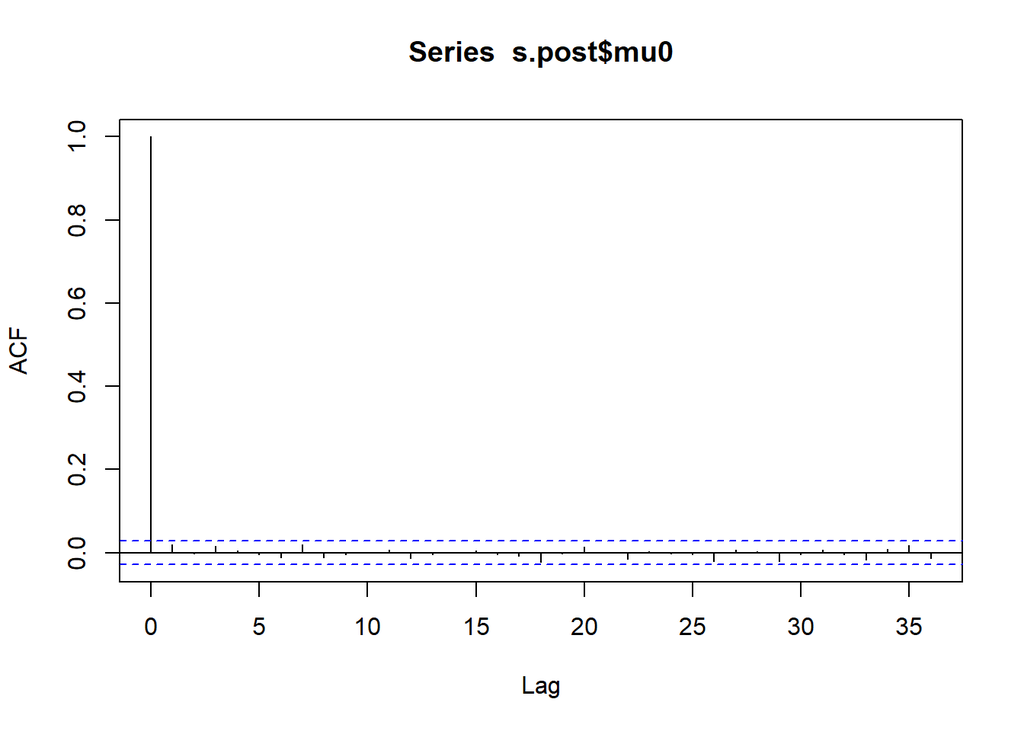

```r
acf(s.post$mu0)
```

```r
### estimativa pontual
summary(s.post$mu[,1])  ### Pcred.1 bayes
```

```
##    Min. 1st Qu.  Median    Mean 3rd Qu.    Max.
##    1811    5615    5951    5919    6235   10322
```

```r
summary(s.post$mu[,2])  ### Pcred.2 bayes
```

```
##    Min. 1st Qu.  Median    Mean 3rd Qu.    Max.
##    2439    5911    6201    6209    6507   10130
```

```r
summary(s.post$mu[,3])  ### Pcred.3 bayes
```

```
##    Min. 1st Qu.  Median    Mean 3rd Qu.    Max.
##    2123    5917    6138    6139    6366    8849
```

```r
summary(s.post$sigma2vet[,1])
```

```
##     Min.  1st Qu.   Median     Mean  3rd Qu.     Max.
##   106682   604096   969765  1434671  1629517 47993414
```

```r
summary(s.post$sigma2vet[,2])
```

```
##     Min.  1st Qu.   Median     Mean  3rd Qu.     Max.
##   137209   604751   966388  1388359  1583310 40731844
```

```r
summary(s.post$sigma2vet[,3])
```

```
##     Min.  1st Qu.   Median     Mean  3rd Qu.     Max.
##    34141   226190   429818   761093   853772 25166870
```

```r
# premio coletivo
summary(s.post$mu0)
```

```
##    Min. 1st Qu.  Median    Mean 3rd Qu.    Max.
## -167513    5714    6087    5935    6458   61134
```